# Simple Linear Regression

### Problem Statement:-

- Build a prediction model for Churn_out_rate

### Data Understanding

```r
emp <- read.csv("~/desktop/Digi 360/Module 6/DataSets-4/emp_data.csv")
head(emp)
```

```
##   Salary_hike Churn_out_rate
## 1        1580             92
## 2        1600             85
## 3        1610             80
## 4        1640             75
## 5        1660             72
## 6        1690             70
```

```r
#renaming the columns
colnames(emp) <- c("hike","churn")
```

```r
# checking the summary
summary(emp)
```

```
##       hike          churn
##  Min.   :1580   Min.   :60.00
##  1st Qu.:1618   1st Qu.:65.75
##  Median :1675   Median :71.00
##  Mean   :1689   Mean   :72.90
##  3rd Qu.:1724   3rd Qu.:78.75
##  Max.   :1870   Max.   :92.00
```

Here, the mean is greater than the median for Salary Hike so the distribution is right skewed.

Similarly, the mean is greater than the median for churn out rate so the distribution is right skewed.

### Visualization

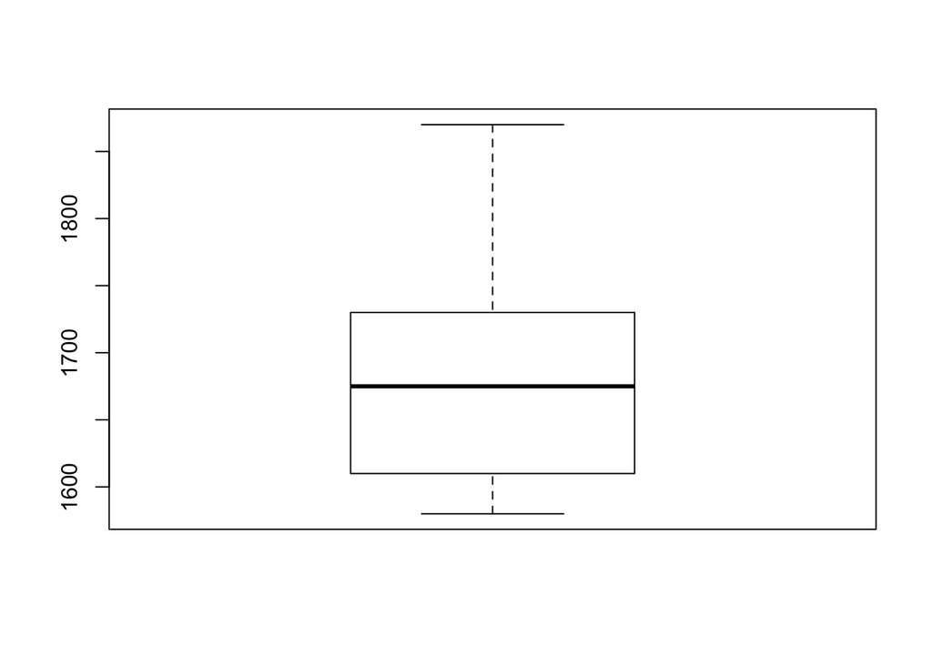

```r
boxplot(emp$hike)
```

So, there are no outliers.

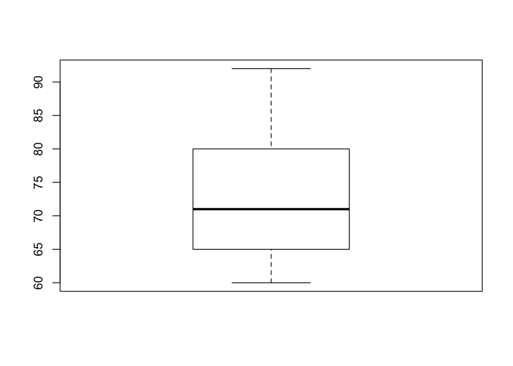

```r
y <- boxplot(emp$churn)
```

```r
y$out
```

```
## numeric(0)
```

So, there are no outliers.

Let’s draw scatter diagram to see the relationship between hike and churn out rate.

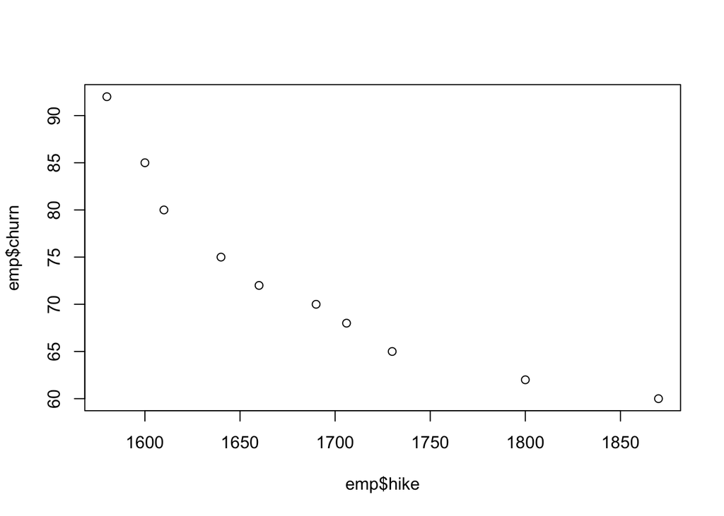

```r
plot(emp$hike,emp$churn) # Scatter plot
```

### Correlation

```r
cor(emp$hike,emp$churn)
```

```
## [1] -0.9117216
```

Here the correlation coefficient value is 0.91 which is greater than 0.85. So, the relationship between salary hike and churn out rate is strong.

### Building the model

```r
model <- lm(emp$churn ~ emp$hike)
summary(model)
```

```
##
## Call:
## lm(formula = emp$churn ~ emp$hike)
##
## Residuals:
##    Min     1Q Median     3Q    Max
## -3.804 -3.059 -1.819  2.430  8.072
##
## Coefficients:
##              Estimate Std. Error t value Pr(>|t|)
## (Intercept) 244.36491   27.35194   8.934 1.96e-05 ***
## emp$hike     -0.10154    0.01618  -6.277 0.000239 ***
## ---
## Signif. codes:  0 '***' 0.001 '**' 0.01 '*' 0.05 '.' 0.1 ' ' 1
##
## Residual standard error: 4.469 on 8 degrees of freedom
## Multiple R-squared:  0.8312, Adjusted R-squared:  0.8101
## F-statistic:  39.4 on 1 and 8 DF,  p-value: 0.0002386
```

So, the linear equation is y^ = 244.3649 – 0.1015x. Here y^ = churn out rate and x = salary hike.

### Model Evolution

Here p value is less than 0.05 so we reject the null hypothesis. That means there is significant correlation between salary hike and churn out rate.

Here we also can see R-squared value is 0.831 which is less than 0.85. Hence our model is not good and we need further transformations.

Since we are ready with equation, let’s predict the values with 95% CI level.

```r
pred <- predict(model, emp)
model$residuals
```

```
##          1          2          3          4          5          6          7
##  8.0724687  3.1033216 -0.8812519 -2.8349726 -3.8041197 -2.7578403 -3.1331580
##          8          9         10
## -3.6961345  0.4118507  5.5198359
```

```r
confint(model, level =0.95)
```

```
##                   2.5 %      97.5 %
## (Intercept) 181.2912317 307.4385905
## emp$hike     -0.1388454  -0.0642399
```

```r
predict(model, interval = "confidence")
```

```
##         fit      lwr      upr
## 1  83.92753 78.72817 89.12690
## 2  81.89668 77.25498 86.53838
## 3  80.88125 76.49733 85.26517
## 4  77.83497 74.10552 81.56443
## 5  75.80412 72.37478 79.23346
## 6  72.75784 69.49825 76.01743
## 7  71.13316 67.80999 74.45633
## 8  68.69613 65.08959 72.30268
## 9  61.58815 56.30700 66.86930
## 10 54.48016 46.96946 61.99087
```

### Accuracy

Now let’s find out the accuracy.

```r
#Finding RMSE
rmse <- sqrt(mean(model$residuals^2))
rmse
```

```
## [1] 3.997528
```

So, we can conclude that our predicted values are 3.99 points deviated from actual values.

Now let’s visualize the predicted values using a ggplot to add a regression line to it.

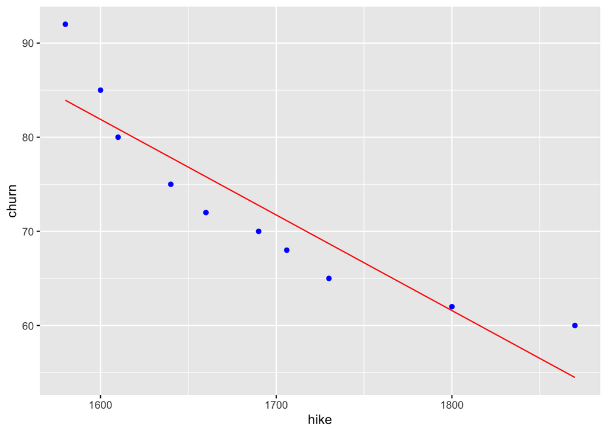

```r
library(ggplot2)
ggplot(data=emp,aes (x = hike, y = churn)) +
 geom_point(color='blue') +
 geom_line(color = 'red', data=emp,aes (x = hike, y = pred))
```

Since our R^2 value 0.83 which is less than 0.85, we need to go for transformations.

### Exponential model

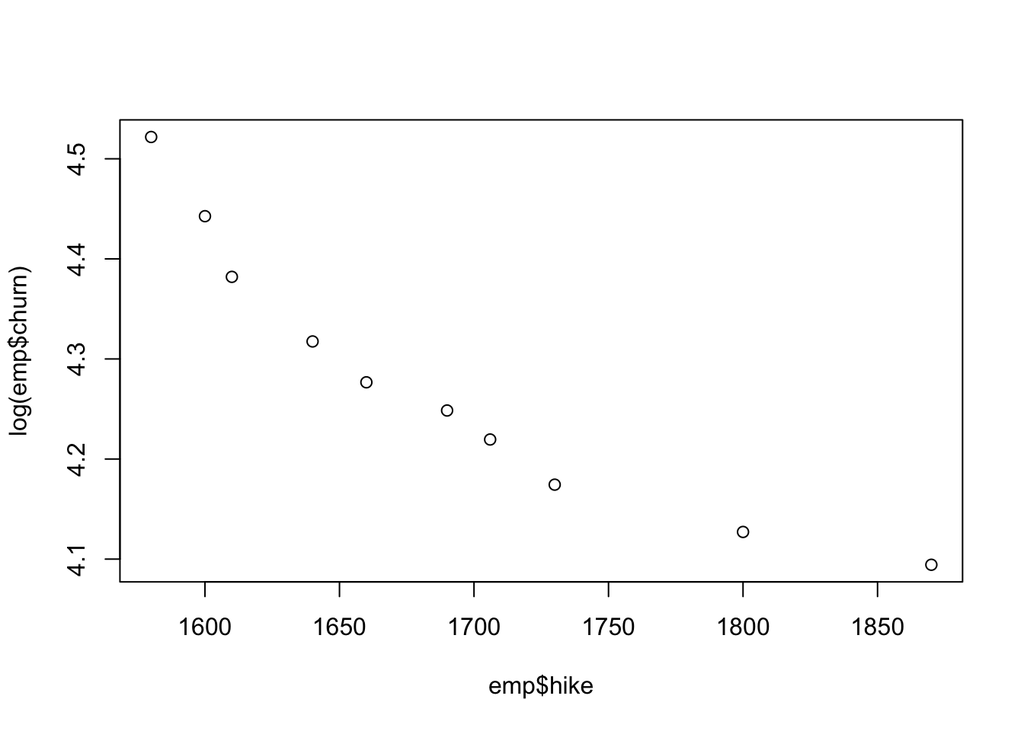

```r
plot(emp$hike,log(emp$churn))
```

```r
model2 <- lm(log(emp$churn) ~ emp$hike)
summary(model2)
```

```
##
## Call:
## lm(formula = log(emp$churn) ~ emp$hike)
##
## Residuals:
##      Min       1Q   Median       3Q      Max
## -0.04825 -0.03519 -0.01909  0.02942  0.08970
##
## Coefficients:
##               Estimate Std. Error t value Pr(>|t|)
## (Intercept)  6.6383000  0.3175983  20.902 2.88e-08 ***
## emp$hike    -0.0013963  0.0001878  -7.434 7.38e-05 ***
## ---
## Signif. codes:  0 '***' 0.001 '**' 0.01 '*' 0.05 '.' 0.1 ' ' 1
##
## Residual standard error: 0.0519 on 8 degrees of freedom
## Multiple R-squared:  0.8735, Adjusted R-squared:  0.8577
## F-statistic: 55.26 on 1 and 8 DF,  p-value: 7.377e-05
```

Since R^2 value 0.87 is greater than 0.85, let’s stop building the model.

```r
log_dt <- predict(model2,interval="confidence")
log_dt
```

```
##         fit      lwr      upr
## 1  4.432091 4.371718 4.492464
## 2  4.404164 4.350267 4.458062
## 3  4.390201 4.339297 4.441105
## 4  4.348311 4.305006 4.391616
## 5  4.320384 4.280564 4.360204
## 6  4.278494 4.240645 4.316343
## 7  4.256153 4.217566 4.294740
## 8  4.222641 4.180763 4.264518
## 9  4.124897 4.063575 4.186220
## 10 4.027154 3.939943 4.114365
```

```r
dt <- exp(log_dt)
dt
```

```
##         fit      lwr      upr
## 1  84.10710 79.17957 89.34128
## 2  81.79076 77.49915 86.32002
## 3  80.65662 76.65362 84.86867
## 4  77.34770 74.06967 80.77081
## 5  75.21752 72.28121 78.27311
## 6  72.13174 69.45265 74.91416
## 7  70.53808 67.86807 73.31314
## 8  68.21338 65.41576 71.13064
## 9  61.86146 58.18194 65.77367
## 10 56.10101 51.41567 61.21331
```

```r
err2 <- emp$churn - dt
err2
```

```
##           fit        lwr       upr
## 1   7.8929033 12.8204329  2.658722
## 2   3.2092422  7.5008494 -1.320018
## 3  -0.6566215  3.3463828 -4.868671
## 4  -2.3477013  0.9303301 -5.770805
## 5  -3.2175185 -0.2812132 -6.273106
## 6  -2.1317363  0.5473454 -4.914161
## 7  -2.5380839  0.1319337 -5.313143
## 8  -3.2133794 -0.4157602 -6.130644
## 9   0.1385450  3.8180627 -3.773671
## 10  3.8989881  8.5843299 -1.213314
```

```r
rmse <- sqrt(mean(err2^2))
rmse
```

```
## [1] 4.682586
```

So, we can conclude that our predicted values are 4.68 points deviated from actual values.

### Conclusion:-

- R^2 with linear model is 0.83
- R^2 with Exponential model is 0.87